# Filter bad contigs, based on coverage

J. Ignacio Lucas Lledó

2024-07-16

Previous runs used a VCF, generated with GATK, to identify contigs with extreme values of depth of coverage. I believe it is faster to use `samtools depth`. The goal is to generate a matrix of coverage per site and sample, isn’t it?

```bash
#BAM=../2023-05-18/BAM
BAM=/nata/mar/crepidostomum2/results/2023-05-18/BAM
#REF=../2023-05-12/farionis2-scaffolds.fa
if [ ! -e depth.txt ]; then
   samtools depth -o depth.txt $BAM/*.bam
fi
```

The resulting matrix is 203 Gb, and I’d rather not load it in R as a matrix. Because all positions where at least one sample is covered by at least one read are reported, the file is unnecessarily large. What I want is a summary of total average depth by contig. That is, one line per contig with the average depth per site across all samples.

```bash
if [ ! -e depth_summary.txt ]; then
   gawk 'BEGIN{
      CONTIG = 0
      COVLEN = 0
      TOTDEP = 0
      TOTSAM = 0
   }{
      if (($1 != CONTIG) && (NR > 1)) {
         print CONTIG "\t" COVLEN "\t" TOTDEP "\t" TOTSAM
         CONTIG = $1
         COVLEN = 0
         TOTDEP = 0
         TOTSAM = 0
      }
      COVLEN += 1
      for (i = 3; i <= NF; i++) {
         TOTDEP += $i
         TOTSAM += ($i > 0)
      }
   }END{
      print CONTIG "\t" COVLEN "\t" TOTDEP "\t" TOTSAM
   }' depth.txt > depth_summary.txt
fi
```

The `depth_summary.txt` file contains contig number, covered length, total depth of coverage, and total number of samples (summed over covered sites). I’d like to compare this to the real length of the contigs, which I can get from the assembly.

```bash
#ASM=../2023-05-12/ILLUMINA/farionis2-scaffolds.fa
ASM=/nata/mar/crepidostomum2/results/2023-05-12/ILLUMINA/farionis2-scaffolds.fa
if [ ! -e assembly_stats.txt ]; then
   gawk '(/^>/){
      CONTIG = $1
      gsub(/>/, "", CONTIG)
   }(/^[^>]/){
      print CONTIG "\t" length($1)
   }' $ASM > assembly_stats.txt
fi
```

The average coverage per site, and average number of samples with coverage of at least 1 need to be calculated dividing by the number of covered bases per contig.

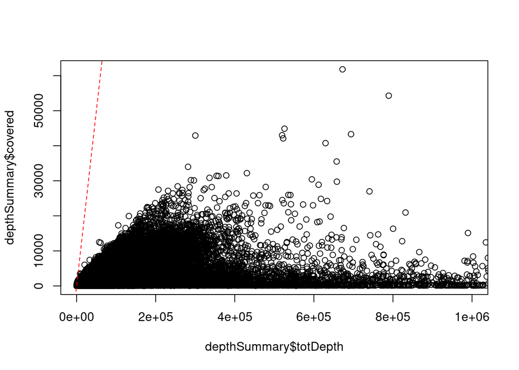

```r
contigLength <- read.table('assembly_stats.txt',
                           col.names = c('contig', 'L'),
                           row.names = 1)
depthSummary <- read.table('depth_summary.txt',
                           col.names = c('contig', 'covered', 'totDepth', 'totSampl'),
                           skip = 1)
depthSummary$totLength <- contigLength[as.character(depthSummary$contig),
                                       'L']
rm(contigLength)
depthSummary$avgDepth <- depthSummary$totDepth / depthSummary$covered
depthSummary$avgSampl <- depthSummary$totSampl / depthSummary$covered

plot(depthSummary$totDepth, depthSummary$covered, xlim = c(0, 1000000))
abline(a = 0, b = 1, col = 'red', lty = 2)
```

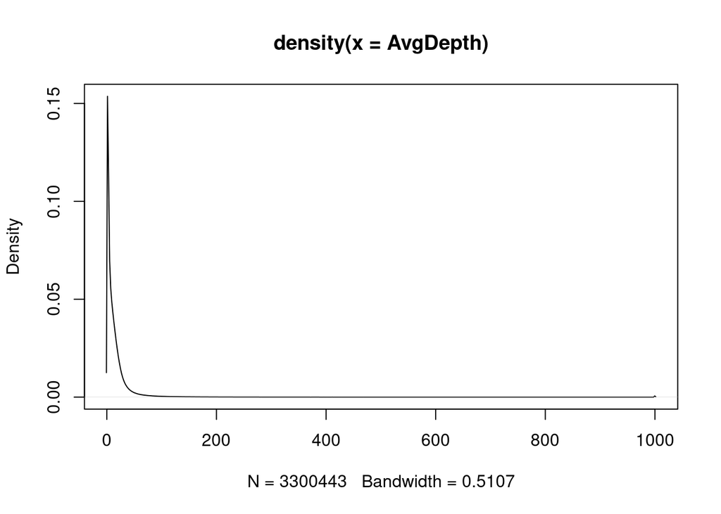

```r
# This plot does not work, too much data?
#plot(density(depthSummary$avgDepth), xlim = c(0, 200))

AvgDepth <- depthSummary$avgDepth
AvgDepth[AvgDepth > 1000] <- 1000
plot(density(AvgDepth))
```

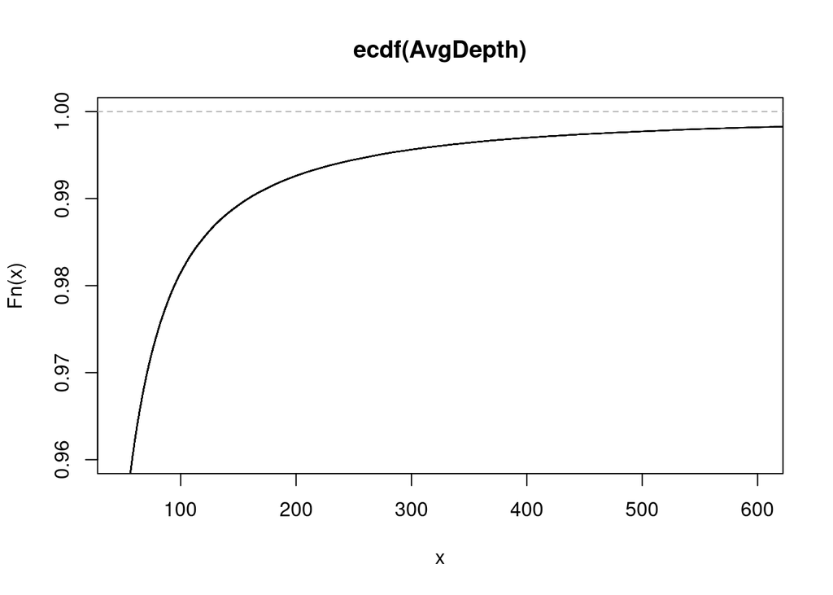

```r
plot(ecdf(AvgDepth), xlim = c(50, 600), ylim = c(0.96, 1.00))
```

```r
rm(AvgDepth)
```

There is no clear cutoff in coverage depth. The decay of frequency with coverage depth is very progressive, making it impossible to choose a reasonable threshold between loci suspected to be affected by collapsed duplication and those that are not. There being 99 samples, coverage depths below 99 cannot have all samples represented.

Let’s see the average number of samples with coverage.

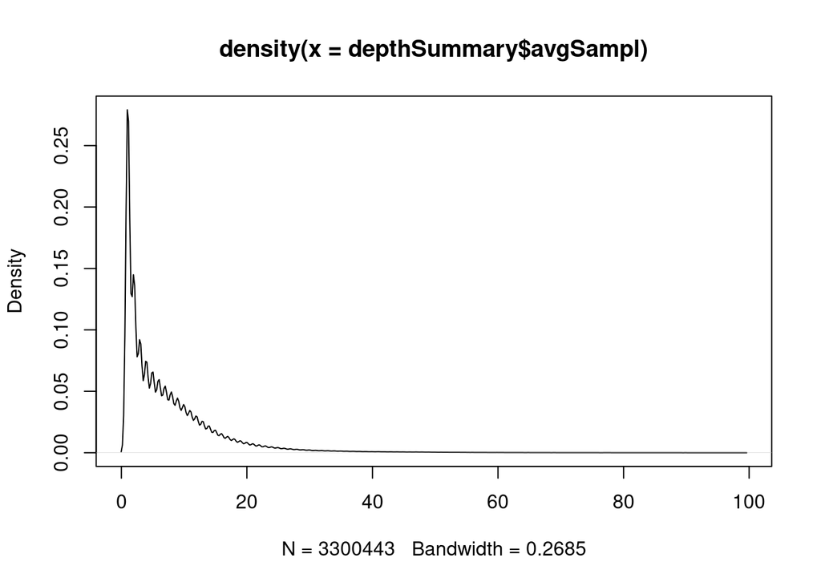

```r
plot(density(depthSummary$avgSampl))
```

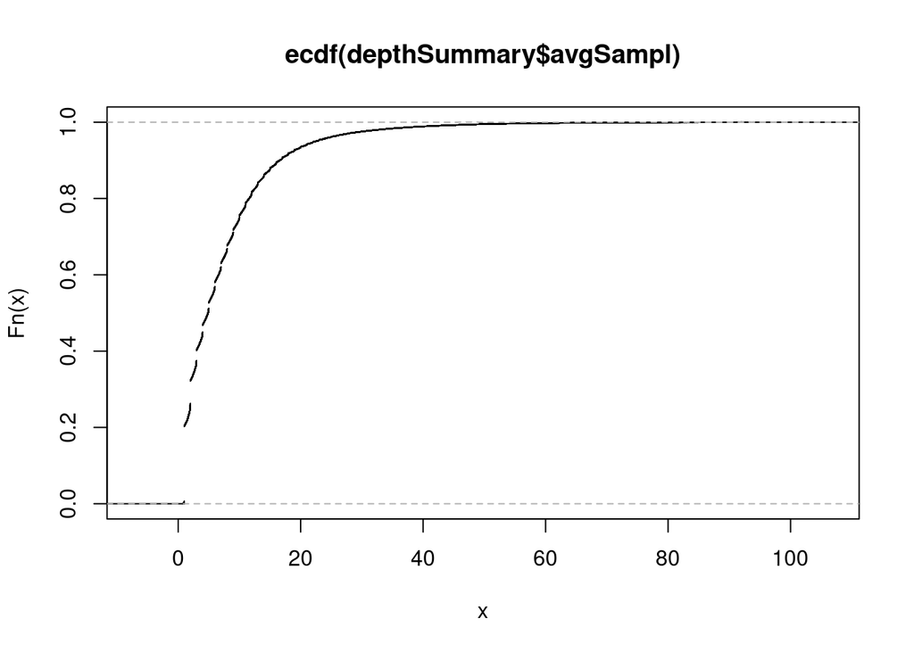

```r
plot(ecdf(depthSummary$avgSampl))
```

Again, there is no clear cutoff threshold. What about the relationship between average depth and average number of samples covered along a contig?

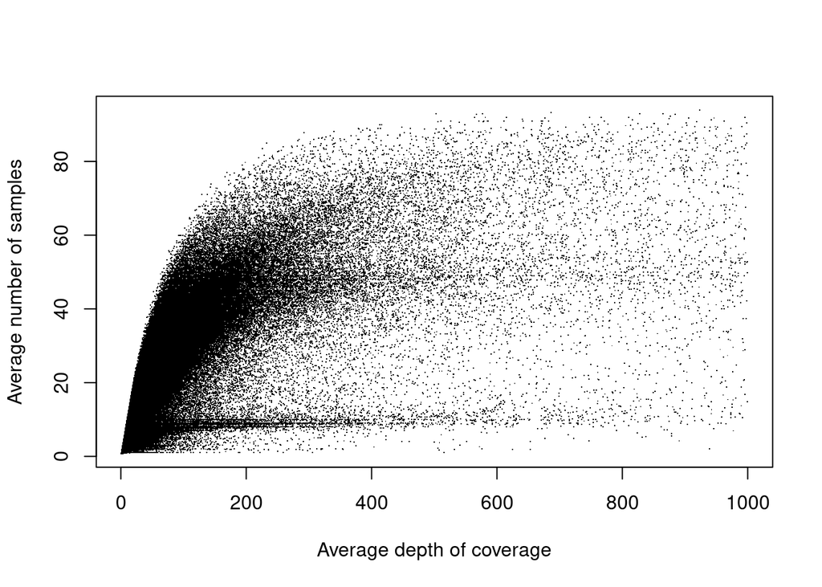

```r
f <- depthSummary$avgDepth < 1000
plot(x = depthSummary[f, 'avgDepth'], y = depthSummary[f, 'avgSampl'],
     xlab = 'Average depth of coverage',
     ylab = 'Average number of samples',
     pch = '.')
```

In the plot above, every dot is a contig, most of which are very short. Three tendencies can be observed. First, the deeper the coverage, the larger fraction of samples get covered, until saturation. This represents the bulk of loci that get sequenced in any sample where the sequencing effort is large enough.

The second pattern is formed by a subset of loci that *resist* to get sequenced in most samples, unless the coverage is extremely high. The reason could be that such loci got over-amplified in only a subset of samples, thus gaining extraordinary depths of coverage, but only thanks to the high coverage in those few samples.

In between these two patterns, a third one can be seen: loci sequenced in more samples the higher the coverage, but only up to some half of the samples.

In any case, the variation in average depth spans so many orders of magnitude that a two or three-fold excess of coverage in some collapsed contigs would go completely unnoticed.

## Conclusions

1. Loci with average or *normal* coverage cannot be sequenced in most samples.
2. For a locus to be sequenced in most samples, it needs a total coverage of more than 300.
3. Removing contigs with high coverage would remove many of the few contigs sequenced in most samples.
4. There seems to be loci that are specific of certain subsets of samples.
5. There is no discontinuity in the distribution of depth of coverage, and therefore, no clear threshold to distinguish badly behaved contigs.
6. At this very early stage of the analysis, a complex or too agressive filtering strategy could bias subsequent results.
7. I propose to remove only the 503 loci with average depth of coverage higher than 5000.

```bash
# Not conditional on purpose, to always re-write BadContigs.txt.
gawk '($3 / $2 > 5000){print $1}' depth_summary.txt > BadContigs.txt
```

It would have been nice to identify mitochondrial contigs and see where they fall in the plots.